# R Notebook

Similarly, you can also draw 1000 random samples from the original data generating process.

```r
set.seed(200) # Setting the seed for replication purposes

sample.size <- 2000 # Sample size

n.samples <- 1000 # Number of bootstrap samples

bootstrap.results <- c() # Creating an empty vector to hold the results

for (i in 1:n.samples)
{
    bootstrap.results[i] <- mean(rnorm(2000,20,4.5)) # Mean of the bootstrap sample
}

length(bootstrap.results) # Sanity check: this should contain the mean of 1000 different samples
```

```
[1] 1000
```

```r
## [1] 1000
summary(bootstrap.results) # Sanity check
```

```
   Min. 1st Qu.  Median    Mean 3rd Qu.    Max.
  19.64   19.93   20.00   20.00   20.07   20.32
```

```r
##    Min. 1st Qu.  Median    Mean 3rd Qu.    Max.
##   19.64   19.93   20.00   20.00   20.07   20.32
sd(bootstrap.results) # Checking the standard deviation of the distribution of means (this is what we are interested in!)
```

```
[1] 0.1041927
```

```r
## [1] 0.1041927
par(mfrow=c(2,1), pin=c(5.8,0.98)) # Combining plots (2 rows, 1 column) and setting the plots size
```

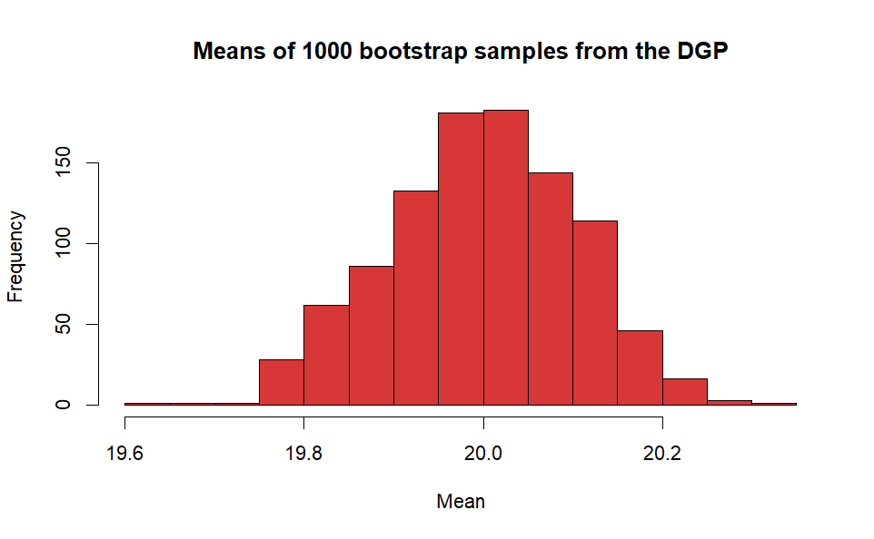

```r
hist(bootstrap.results, # Creating an histogram
     col="#d83737", # Changing the color
     xlab="Mean", # Giving a label to the x axis
     main=paste("Means of 1000 bootstrap samples from the DGP")) # Giving a title to the graph
```

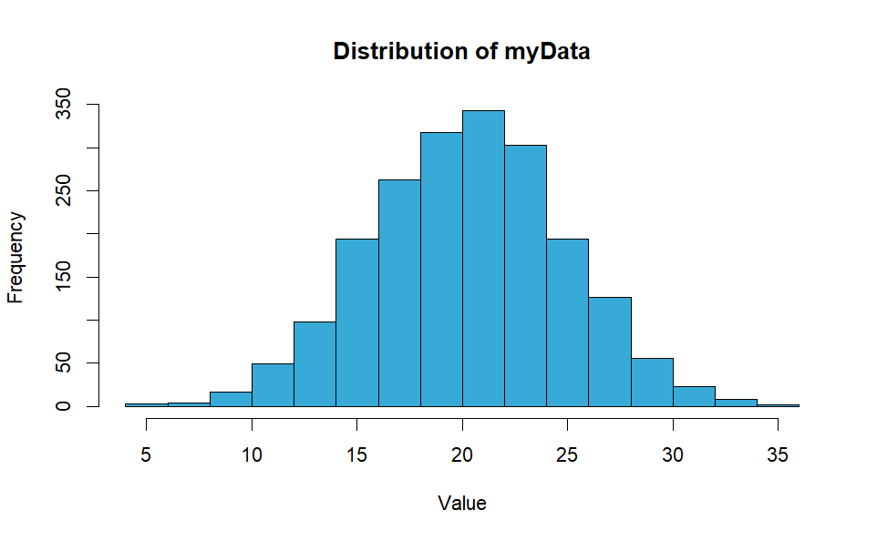

```r
hist(myData, # Creating an histogram
     col="#37aad8", # Changing the color
     xlab="Value", # Giving a label to the x axis
     main=paste("Distribution of myData")) # Giving a title to the graph
```

Exercises Exercise 1 Set your seed at 150. Generate a random normal distribution of 1000 observations, with a mean of 30 and a standard deviation of 2.5. Calculate the mean of 50 samples of 1000 observations from that dataset. Store your results in a vector.

Relevant functions: set.seed(), rnorm(), for(i in x), sample().

Exercise 2 Generate two histograms to graphically display the distribution of means obtained in Exercise 1 as well as the values of the 1000 observations within your original data set. Combine these histograms into one overall graph.

Relevant functions: par(), hist().